# Practical Lab 2: Multivariate Linear Regression, Non-Parametric Models and Cross-Validation

## 10. Plot a graph of the train, validation and test data points, and the fit of the chosen model over each of them (1 point).

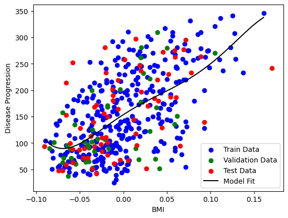

```python
plt.scatter(X_bmi_train, y_train, color='blue', label='Train Data')
plt.scatter(X_bmi_val, y_val, color='green', label='Validation Data')
plt.scatter(X_bmi_test, y_test, color='red', label='Test Data')

X_range = np.linspace(X_bmi_train.min(), X_bmi_train.max(), 100).reshape(-1, 1)
y_range_pred = model.predict(poly.transform(X_range))

plt.plot(X_range , y_range_pred, color='black', label='Model Fit')
plt.xlabel('BMI')
plt.ylabel('Disease Progression')
plt.legend()
plt.show()
```

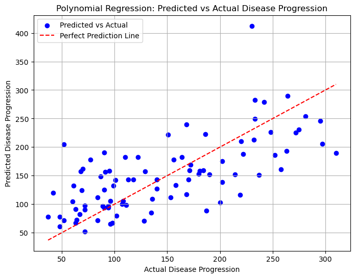

```python
import matplotlib.pyplot as plt
import numpy as np
from sklearn.model_selection import train_test_split

# Split the data into training and test sets
X_train, X_test, y_train, y_test = train_test_split(X_poly, y, test_size=0.2, random_state=42)

# Fit the polynomial regression model on the training data
poly_model.fit(X_train, y_train)

# Predict on the test data
y_pred = poly_model.predict(X_test)

# Plot actual vs predicted values
plt.figure(figsize=(8, 6))
plt.scatter(y_test, y_pred, color='blue', label='Predicted vs Actual')
plt.plot([min(y_test), max(y_test)], [min(y_test), max(y_test)], color='red', linestyle='--', label='Perfect Prediction Line')
plt.xlabel('Actual Disease Progression')
plt.ylabel('Predicted Disease Progression')
plt.title('Polynomial Regression: Predicted vs Actual Disease Progression')
plt.legend()
plt.grid(True)
plt.show()
```

## 12: Predict Diabetes Progression for a BMI value

```python
bmi_value = 38  # Example BMI value
predicted_progression = model.predict(poly.transform([[bmi_value]]))
print(f"Predicted Diabetes Progression for BMI={bmi_value}: {predicted_progression}")
```

```
Predicted Diabetes Progression for BMI=38: [-2.35636947e+14]
```

```python
#Determine the number of trainable parameters using PolynomialFeatures
from sklearn.preprocessing import PolynomialFeatures

# Assuming you are working with polynomial features, e.g., degree 2 or 3
# Let's use the degree 3 polynomial features for this step

# Create polynomial features of degree 3
poly_features_2 = PolynomialFeatures(degree=3)
X_poly_2 = poly_features_2.fit_transform(X)

# Get the feature names
feature_names = poly_features_2.get_feature_names_out(input_features=X.columns)

# Output the number of features (trainable parameters)
num_trainable_params = len(feature_names)

# Print results
print(f"Number of trainable parameters (degree 3): {num_trainable_params}")
```

```
Number of trainable parameters (degree 3): 286
```

## Conclusion

### In summary, while the polynomial model showed moderate predictive performance on the validation set, its high error rates on the test set and difficulty in handling outliers or extreme cases highlight its limitations. Further improvements could include using regularization techniques or more complex models like decision trees or neural networks.

# Part 3: Multivariate Models

## 1: Polynomial Models

Fit two multivariate polynomial models with degrees > 1 using all features or a subset based on EDA insights.

```python
from sklearn.preprocessing import PolynomialFeatures
from sklearn.linear_model import LinearRegression

# Define two polynomial degrees for multivariate models
degrees = [2, 3]

multivariate_results = []


# Splitting the dataset into train and test sets
X_train, X_test, y_train, y_test = train_test_split(X, y, test_size=0.2, random_state=42)

for degree in degrees:
    # Polynomial feature transformation
    poly = PolynomialFeatures(degree=degree)
    X_poly_train = poly.fit_transform(X_train)
    X_poly_val = poly.transform(X_val)

    # Train the model
    model = LinearRegression()
    model.fit(X_poly_train, y_train)

    # Predictions on training and validation sets
    y_train_pred = model.predict(X_poly_train)
    y_val_pred = model.predict(X_poly_val)

    # Evaluation metrics
    train_r2 = model.score(X_poly_train, y_train)
    val_r2 = model.score(X_poly_val, y_val)
    train_mae = mean_absolute_error(y_train, y_train_pred)
    val_mae = mean_absolute_error(y_val, y_val_pred)
    train_mape = np.mean(np.abs((y_train - y_train_pred) / y_train)) * 100
    val_mape = np.mean(np.abs((y_val - y_val_pred) / y_val)) * 100

    multivariate_results.append({
        'Degree': degree,
        'Train R-squared': train_r2,
        'Validation R-squared': val_r2,
        'Train MAE': train_mae,
        'Validation MAE': val_mae,
        'Train MAPE': train_mape,
        'Validation MAPE': val_mape
    })

# Convert results into a DataFrame for easy viewing
multivariate_results_df = pd.DataFrame(multivariate_results)
multivariate_results_df
```

|  | Degree | Train R-squared | Validation R-squared | Train MAE | Validation MAE | Train MAPE | Validation MAPE |
| --- | --- | --- | --- | --- | --- | --- | --- |
| 0 | 2 | 0.606158 | 0.486783 | 39.14261 | 38.94148 | 34.390240 | 38.895627 |
| 1 | 3 | 0.481480 | -12.258780 | 46.01983 | 146.75000 | 45.218259 | 172.401678 |

## 2. Two decision trees

Use the DecisionTreeRegressor with different max_depth values (e.g., 3 and 5).

```python
from sklearn.tree import DecisionTreeRegressor

# Two decision trees with different max_depth
tree_depths = [3, 5]
tree_results = []

for depth in tree_depths:
    # Train decision tree model
    tree_model = DecisionTreeRegressor(max_depth=depth, random_state=42)
    tree_model.fit(X_train, y_train)

    # Predictions on training and validation sets
    y_train_pred = tree_model.predict(X_train)
    y_val_pred = tree_model.predict(X_val)

    # Evaluation metrics
    train_r2 = tree_model.score(X_train, y_train)
    val_r2 = tree_model.score(X_val, y_val)
    train_mae = mean_absolute_error(y_train, y_train_pred)
    val_mae = mean_absolute_error(y_val, y_val_pred)
    train_mape = np.mean(np.abs((y_train - y_train_pred) / y_train)) * 100
    val_mape = np.mean(np.abs((y_val - y_val_pred) / y_val)) * 100

    tree_results.append({
        'Max Depth': depth,
        'Train R-squared': train_r2,
        'Validation R-squared': val_r2,
        'Train MAE': train_mae,
        'Validation MAE': val_mae,
        'Train MAPE': train_mape,
        'Validation MAPE': val_mape
    })

# Convert results into a DataFrame for easy viewing
tree_results_df = pd.DataFrame(tree_results)
tree_results_df
```

|  | Max Depth | Train R-squared | Validation R-squared | Train MAE | Validation MAE | Train MAPE | Validation MAPE |
| --- | --- | --- | --- | --- | --- | --- | --- |
| 0 | 3 | 0.516977 | 0.240386 | 43.682417 | 47.010952 | 38.737396 | 46.584534 |
| 1 | 5 | 0.668606 | 0.196365 | 35.251864 | 46.909242 | 30.579846 | 46.650160 |

## 3. k-Nearest Neighbors (kNNs)

Use the KNeighborsRegressor with different k values (e.g., 3 and 5).

```python
from sklearn.neighbors import KNeighborsRegressor

# Two kNN models with different k values
k_values = [3, 5]
knn_results = []

for k in k_values:
    # Train kNN model
    knn_model = KNeighborsRegressor(n_neighbors=k)
    knn_model.fit(X_train, y_train)

    # Predictions on training and validation sets
    y_train_pred = knn_model.predict(X_train)
    y_val_pred = knn_model.predict(X_val)

    # Evaluation metrics
    train_r2 = knn_model.score(X_train, y_train)
    val_r2 = knn_model.score(X_val, y_val)
    train_mae = mean_absolute_error(y_train, y_train_pred)
    val_mae = mean_absolute_error(y_val, y_val_pred)
    train_mape = np.mean(np.abs((y_train - y_train_pred) / y_train)) * 100
    val_mape = np.mean(np.abs((y_val - y_val_pred) / y_val)) * 100

    knn_results.append({
        'k': k,
        'Train R-squared': train_r2,
        'Validation R-squared': val_r2,
        'Train MAE': train_mae,
        'Validation MAE': val_mae,
        'Train MAPE': train_mape,
        'Validation MAPE': val_mape
    })

# Convert results into a DataFrame for easy viewing
knn_results_df = pd.DataFrame(knn_results)
knn_results_df
```

|  | k | Train R-squared | Validation R-squared | Train MAE | Validation MAE | Train MAPE | Validation MAPE |
| --- | --- | --- | --- | --- | --- | --- | --- |
| 0 | 3 | 0.635817 | 0.353844 | 36.486308 | 40.204545 | 31.025042 | 40.611429 |
| 1 | 5 | 0.583867 | 0.436014 | 39.666289 | 40.177273 | 34.375408 | 38.067154 |

```python
# Combine all results into one summary table
all_results_df = pd.concat([multivariate_results_df, tree_results_df, knn_results_df], ignore_index=True)
all_results_df
```

|  | Degree | Train R-squared | Validation R-squared | Train MAE | Validation MAE | Train MAPE | Validation MAPE | Max Depth | k |
| --- | --- | --- | --- | --- | --- | --- | --- | --- | --- |
| 0 | 2.0 | 0.606158 | 0.486783 | 39.142610 | 38.941480 | 34.390240 | 38.895627 | NaN | NaN |
| 1 | 3.0 | 0.481480 | -12.258780 | 46.019830 | 146.750000 | 45.218259 | 172.401678 | NaN | NaN |
| 2 | NaN | 0.516977 | 0.240386 | 43.682417 | 47.010952 | 38.737396 | 46.584534 | 3.0 | NaN |
| 3 | NaN | 0.668606 | 0.196365 | 35.251864 | 46.909242 | 30.579846 | 46.650160 | 5.0 | NaN |
| 4 | NaN | 0.635817 | 0.353844 | 36.486308 | 40.204545 | 31.025042 | 40.611429 | NaN | 3.0 |
| 5 | NaN | 0.583867 | 0.436014 | 39.666289 | 40.177273 | 34.375408 | 38.067154 | NaN | 5.0 |